# Defaulted Prosper Loans

## by Brian Yatich

## Investigation Overview

> The income range of between 25,000-49,000 had the most loan default frequency. Under further scrutiny, it was observed that this was due to the fact that this range of income had the highest interest rate on their loans. I also observed that loan amounts within the range of 0 - 5000 had the highest rate of defaults and this was because this loan range had the highest average interest rates. Also, Loan defaulters with a monthly income range of between 0-10,000 had the highest frequency of defaults. A general decrease in loan defaults was seen with an increase in monthly income

> From the heatmap, the strongest featured correlation in defaulted loans of the Prosper Loan Data set is the relation between monthly payments and the loan amount. The correlation show that with every increase in loan amount, there is a corresponding increae in the monthly payments

## Dataset Overview

> The Prosper loan dataset contains 113,937 loans with 81 variables on each loan, including loan status, loan amount, borrower rate, borrower income range, among others

## Distribution of loan default counts with respect to annual income range

The income range of between 25,000-49,000 had the most loan default frequency. Under further scrutiny, it was observed that this was due to the fact that this range of income had the highest interest rate on their loans.

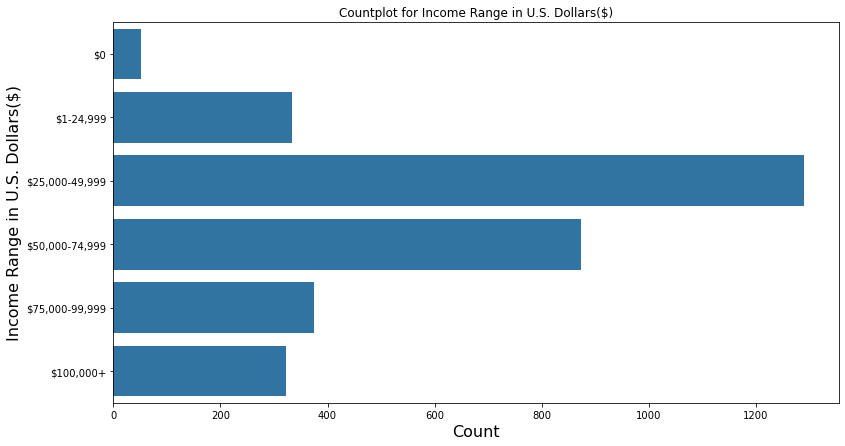

## Interest Rate vs Income Range

Under further scrutiny, it was observed that this was due to the fact that this range of income had the highest interest rate on their loans as shown by the boxplot in the next slide

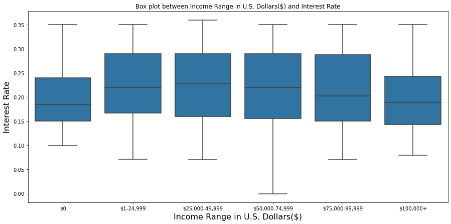

## Distribution of loan defaults with respect to monthly income range

Loan defaulters with a monthly income range of between $0-10,000 had the highest frequency of defaults. A general decrease in loan defaults was seen with an increase in monthly income. The distribution is shown in the next slide.

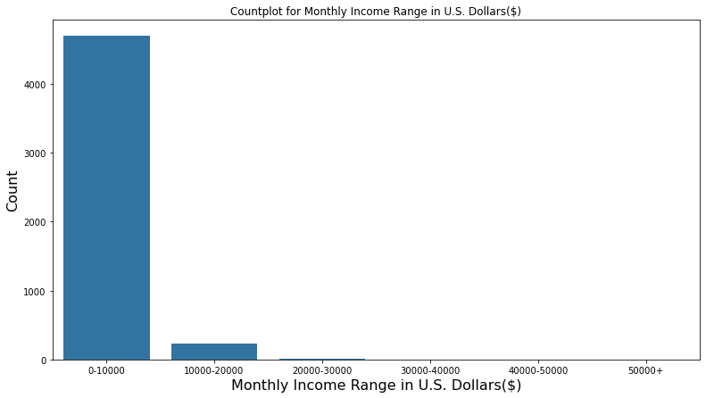

## Interest Rate vs Monthly Income Range

Loanees who defaulted on loans with a steady monthly income of between $0 - 10,000 also had the highest interest rate on their loans compared to the other , monthly income ranges. A decrease in loan interest rates is also observed with an increase in monthly income range

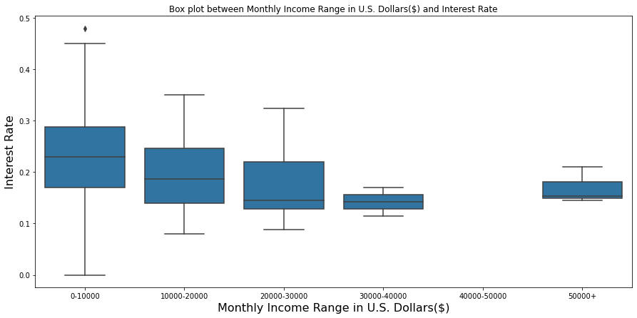

## Heatmap Correlation

The strongest featured correlation in defaulted loans of the Prosper Loan Data set is the relation between Monthly payments and the loan amounts

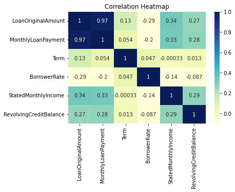

## Monthly loan payment vs Loan amount

This is the strongest correlation of the factors that I considered in this loan analysis activity. It show that an increase in loan amounts defaulted resulted in an increase in the monthly payments

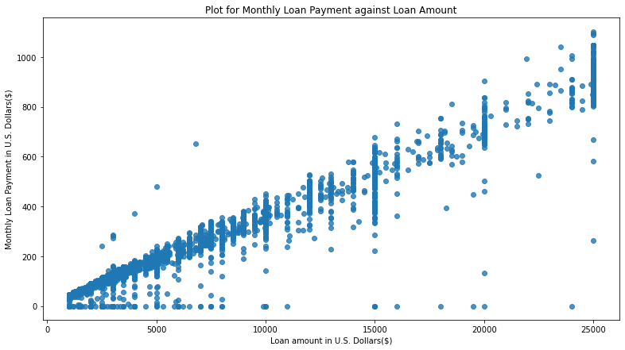